# Skills for Analysis Assignment 2

GSD SES 5394

Spring 2022

# Overview

The followings skills will be useful for Analysis Assignment 2. They are listed here alphabetically. I don’t want to bias your thinking about which ones you’ll end up using and in what order. But this page will be a useful reference.

*Note: In general, you should load all your libraries at the beginning of your script or markdown file. In these examples, I’m loading libraries at the top of each code chunk to make it more clear which methods use which packages.*

- **Apply a ggplot theme:** You have a lot of flexibility in designing your ggplot charts and maps, but some pre-defined themes can save you some time on that.
- **Calculate an area:** A lot of the variables you’re likely to be working with are counts (e.g. number of households or number of jobs). When you show those on a chloropleth map, you might decide that a density (e.g. jobs or households per square mile) is more informative. Or you might even decide a density is one of the variables you want to include in your model. Before you can calculate a density, you’ll need to calculate the area of each zone (for example, in square miles or square kilometers).
- **Calculate new variables:** When you download data from the census or from LEHD, you might need to combine multiple variables together to get the variable you actually want. For example, you might need to add the number of households in each of multiple income categories to get the number in a combined income category, or you might need to divide the number of jobs by the area of each tract to get an employment density.
- **Collapse data:** This is useful if you want to collapse block-level data to the tract level, or tract-level data to the region level.
- **Convert units:** When you calculate an area, the result will be in the units of your projected coordinate system (typically feet or meters). You may want to convert the units to something like acres or square miles.
- **Create a chloropleth map:** A static chloropleth map is a useful way to display variation across space on a figure you want to include in report.
- **Create a dot-density map:** A dot-density map can be useful for visualizing how the densities of things in one or more categories vary across space, without having to actually calculate densities.
- **Create a histogram:** A histogram is a helpful way to illustrate the variation in a variable.
- **Create an interactive map:** Even if your deliverable will be all static content in a report, it can be helpful to create an interactive map for your own use to explore your data. For example, it’s a useful way to find the GEOID for a zone in a specific location.
- **Create a tree map:** Tree maps are nice way to visualize proportions while avoiding some of the pitfalls of pie charts.
- **Customize axes and legends:** You’ll likely want to define titles for the axes and legends on any graphics you create. You might also want to control how number are displayed on axes and legends.
- **Define a color ramp:** There are several predefined color palettes you can use, and some useful functions you can use to select colors in `ggplot`.
- **Define study area boundary:** In this class, your study area is a metropolitan statistical area. You can use the `tigris` or `tidycensus` package to get the boundary of your study area. This can be especially useful if your study area includes many counties.
- **Download census tract data:** You’ll need to download several tract-level variables from the census. You’ll find the `tidycensus` package super useful for this.
- **Download employment data:** The Longitudinal Employer-Household Dynamica (LEHD) dataset is a great source of census-block level employment data by industry.
- **Find census variables:** You’ll need to search for the names of the variables you want to include in your analysis.
- **Get regional data:** Your analysis will be at the tract level, but you might want to calculate some regional-level statistics as well - either because you want to just give a description of the region as a whole in your report or because you want to calculate a variable that reports tract-level statistics to regional statistics (e.g. income relative to the regional median).
- **Join two data frames:** If you have employment data in one dataframe and population data in another, you’ll want to combine them into a single dataframe.
- **List census variable names:** Once you’ve identified the census variable you want to include in your analysis, you can create a list of them in which you define your own variable names.
- **Organize data columns:** At some point, you’ll find you have more columns in your dataframe that you need. You can use the `select()` function to delete variables you don’t need and also to reorder columns.
- **Separate geometry from dataset:** You might have situations where you only need the zone boundaries, or you only need the zone data without the boundaries. You can separate them out before you save them.
- **Summarize tract statistics:** Histograms and maps are great, but a table can also be really informative.
- **Write data to a file:** When you have all the data how you want it, you should save it so you can use it for subsequent assignments.
- **Write figures to a file:** Creating maps and charts in RMarkdown is great, but you’ll eventually want to save them as files you can include in a report or presentation.

# Apply a ggplot theme

You have a lot of flexibility in designing your ggplot charts and maps, but some pre-defined themes can save you some time on that.

Here’s a histogram with the default theme (see how you would have created it in the “Create a histogram” topic).

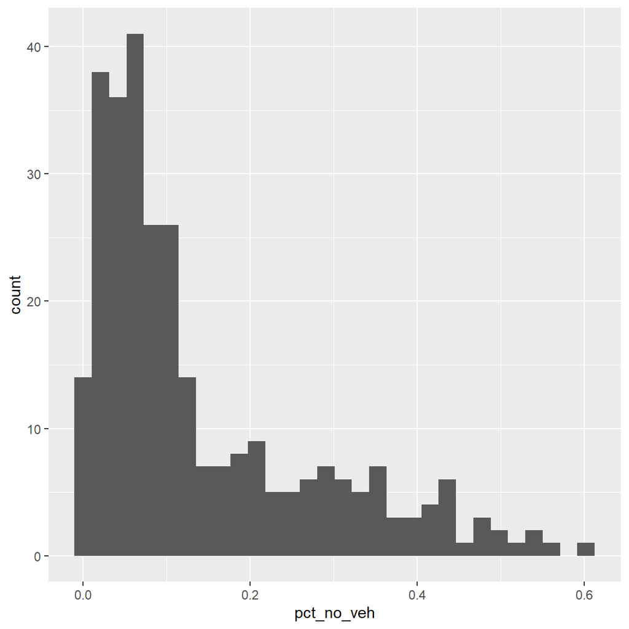

```r
hist
```

`theme_bw()` gives a nice, clean look.

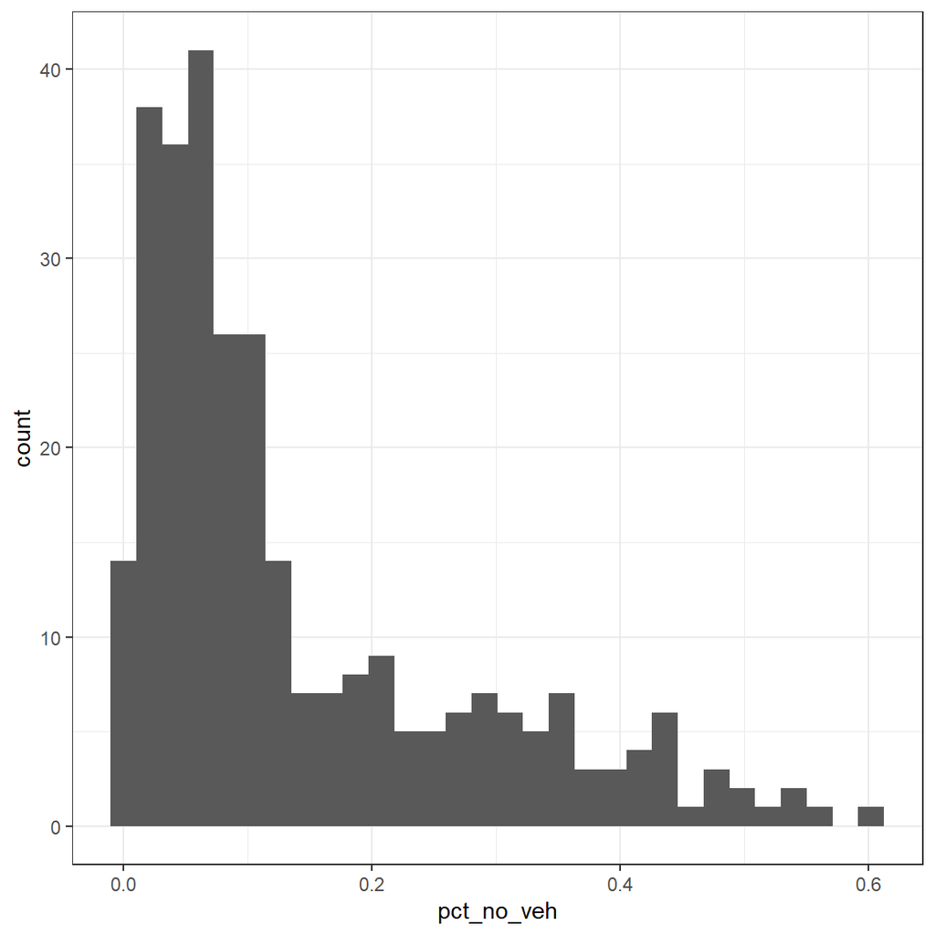

```r
hist +
  theme_bw()
```

If you want to try something even more minimal, you could try `theme_minimal()`

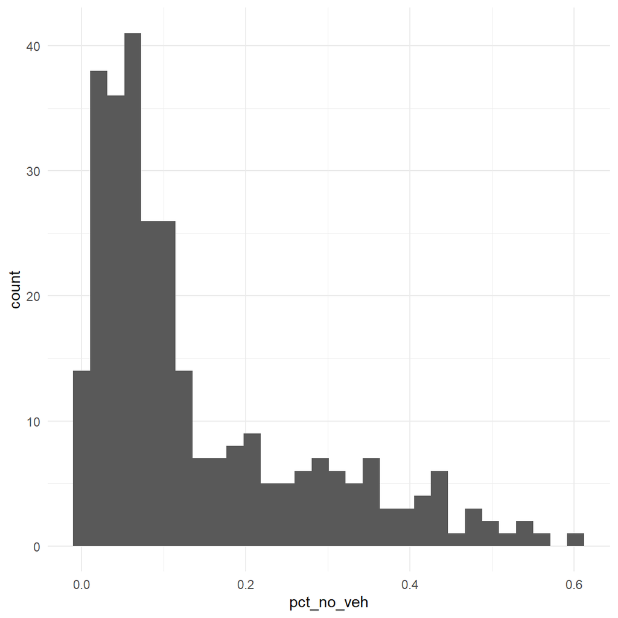

```r
hist +
  theme_minimal()
```

There are a few other themes included in `tidyverse`. To see your options, just start typing `theme_` and some autocomplete options will appear.

If you want even more themes to choose from, you could try the `ggthemes` package. `theme_few()` is based on guidelines from [Stephen Few](http://www.stephen-few.com/smtn.php).

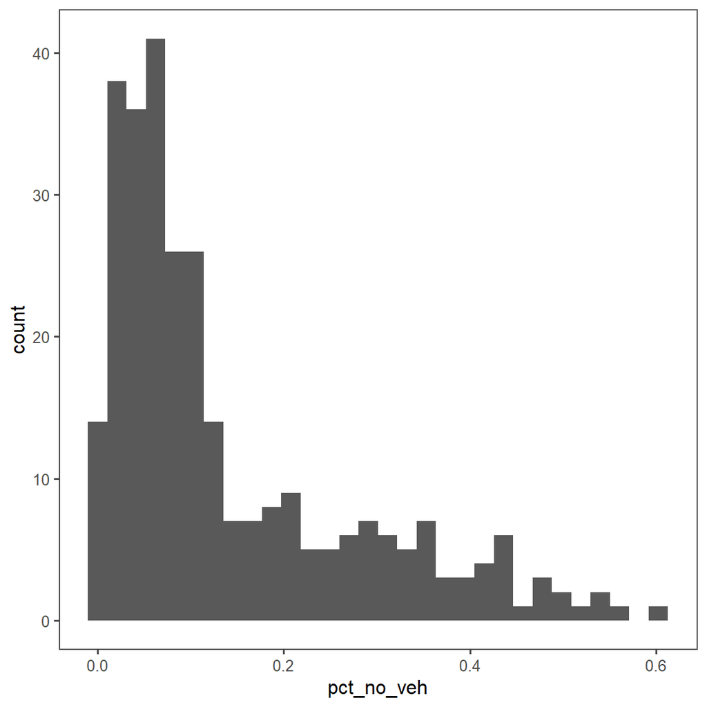

```r
library(ggthemes)

hist +
  theme_few()
```

`theme_tufte()` is based on guidelines from [Edward Tufte](https://www.edwardtufte.com/tufte/books_vdqi).

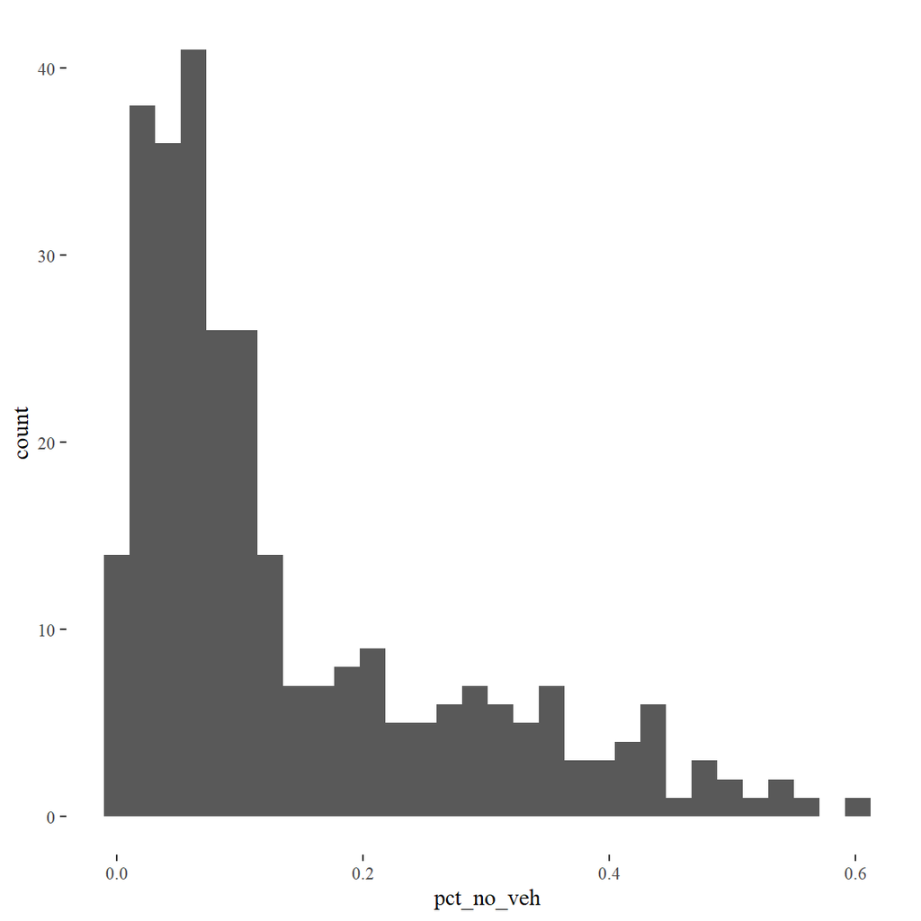

```r
library(ggthemes)

hist +
  theme_tufte()
```

For maps, `theme_map()` can be a good choice. If you’ve [created a chloropleth map](https://gsd-ses-5394-s2022.github.io/Richmond/a2_skills.html#create-a-chloropleth-map) called `hh_size_map`, you could apply `theme_map()` like this.

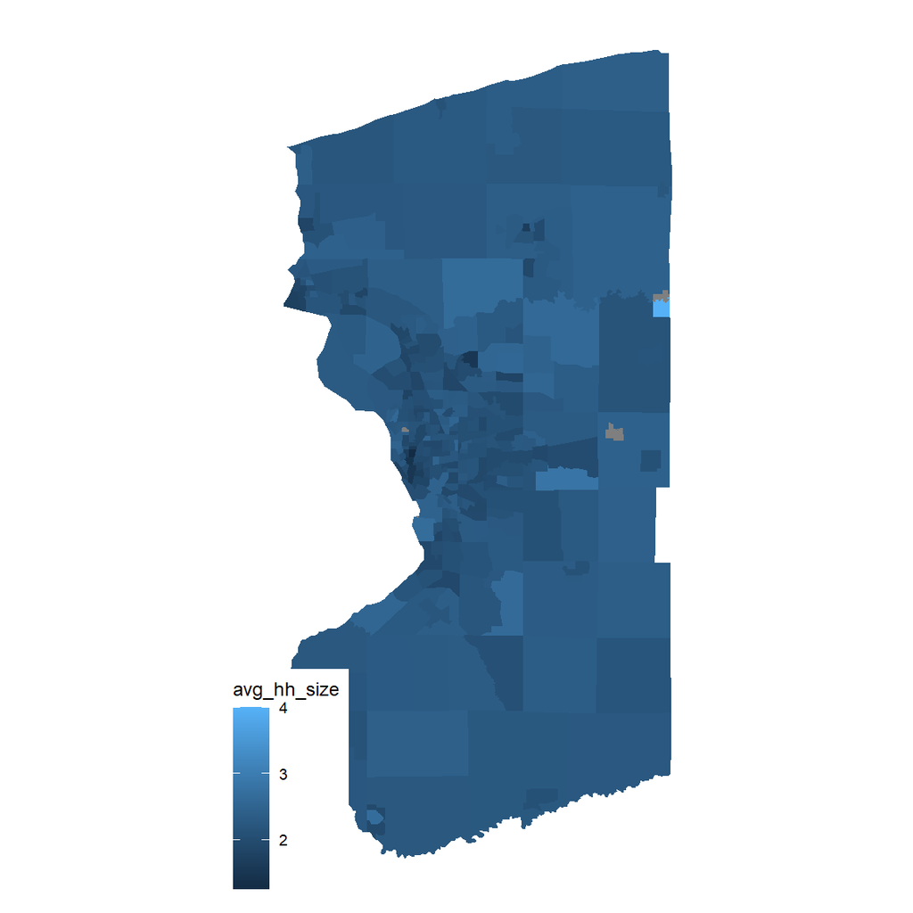

```r
library(ggthemes)

hh_size_map +
  theme_map()
```

That will overlap the legend with the map, which you won’t always want. `theme_void()` can be a good alternative.

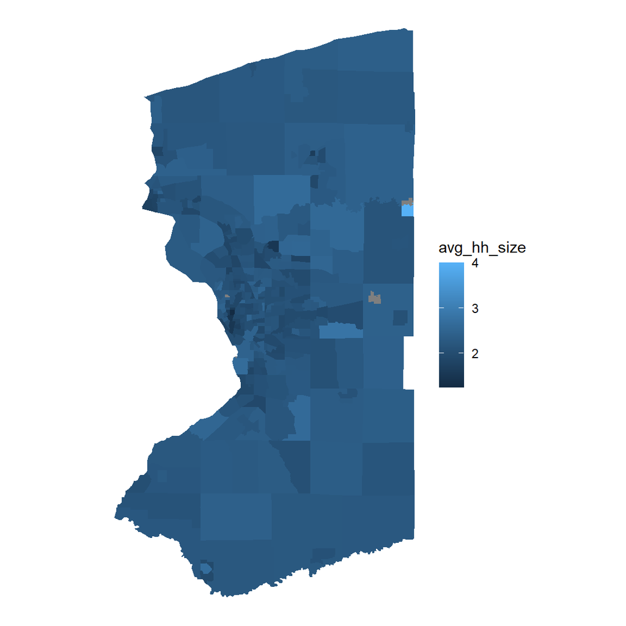

```r
library(tidyverse)

hh_size_map +
  theme_void()
```

# Calculate an area

A lot of the variables you’re likely to be working with are counts (e.g. number of households or number of jobs). When you show those on a chloropleth map, you might decide that a density (e.g. jobs or households per square mile) is more informative. Or you might even decide a density is one of the variables you want to include in your model. Before you can calculate a density, you’ll need to calculate the area of each zone (for example, in square miles or square kilometers).

Let’s say I’ve already loaded data on my zones, including the zone boundaries. I can create a new variable called `tract_area` using mutate() and calculate the value of that variable as the area of each zone using `st_area()`.

```r
library(tidyverse)

census <- census %>%
  mutate(tract_area = st_area(geometry))
```

You’ll notice that the area is given in square meters, which might not be what you want. You may want to [convert the units](https://gsd-ses-5394-s2022.github.io/Richmond/a2_skills.html#convert-units) to square miles or square kilometers or acres or something.

# Calculate new variables

When you download data from the census or from LEHD, you might need to combine multiple variables together to get the variable you actually want. For example, you might need to add the number of households in each of multiple income categories to get the number in a combined income category, or you might need to divide the number of jobs by the area of each tract to get an employment density.

If you’ve just [downloaded your census data](https://gsd-ses-5394-s2022.github.io/Richmond/a2_skills.html#download-census-tract-data) into a dataframe called `census`, you’ll probably need to combine some of your variables into new variables.

For example, you might have variables for 16 different income categories, and you only want five income categories (perhaps based on [regional quintiles](https://gsd-ses-5394-s2022.github.io/Richmond/a2_skills.html#get-regional-data)).

Notice that the variable names in your dataframe differ from the ones you [may have specified](https://gsd-ses-5394-s2022.github.io/Richmond/a2_skills.html#list-census-variable-names). The `get_acs` function creates two columns for each variable. The estimated value is in a column with the name you specified with an E appended (E for estimate). There is also a column with the name you specified and an M appended to indicate the margin of error for that estimate.

```r
library(tidyverse)

census <- census %>%
  mutate(inc_quint_1 = inc_lt_10kE +
                       inc_btw_10k_15kE +
                       inc_btw_15k_20kE +
                       inc_btw_20k_25kE,
         inc_quint_2 = inc_btw_25k_30kE +
                       inc_btw_30k_35kE +
                       inc_btw_35k_40kE +
                       inc_btw_40k_45kE +
                       inc_btw_45k_50kE,
         inc_quint_3 = inc_btw_50k_60kE +
                       inc_btw_60k_75kE,
         inc_quint_4 = inc_btw_75k_100kE,
         inc_quint_5 = inc_btw_100k_125kE +
                       inc_btw_125k_150kE +
                       inc_btw_150k_200kE +
                       inc_gt_200kE)
```

# Collapse data

This is useful if you want to collapse block-level data to the tract level. So for example, you might use it if you just [loaded the LEHD data](https://gsd-ses-5394-s2022.github.io/Richmond/a2_skills.html#download-employment-data).

In LEHD data, the GEOID is in a variable called w_geocode, and it’s stored as a number, so we’ll convert it to a character. The first 11 digits of census block’s GEOID indicate the census tract, so we’ll use that to create a variable indicating the census tract, and we’ll name *that* GEOID. Then we’ll drop the `w_geocode` column (by putting a negative sign before its name in the `select()` function). Then we’ll use `group_by()` and `summarize()` to collapse the data to the tract level.

```r
library(tidyverse)

lehd_tracts <- lehd_blocks %>%
  mutate(w_geocode = as.character(w_geocode)) %>%
  mutate(GEOID = substr(w_geocode, 1, 11)) %>%
  select(-w_geocode) %>%
  group_by(GEOID) %>%
  summarize(across(everything(), ~sum(.)))
```

Now I have the total employment in each of these categories for every census tract in the state. I’d want to filter that down to just my study area, but if I already have the population data for my study area (see the “Download census tract data” topic) for my study area, I can just join the two dataframes (see the “Join two data frames” topic) and that will take care of the filtering.

# Convert units

When you calculate an area, the result will be in the units of your projected coordinate system (typically square feet or square meters) or in square meters if you’re using a geographic coordinate system like WGS 84. You may want to convert the units to something like acres (`acres`), square kilometers (`km2`) or square miles (`mi2`).

```r
library(units)

census <- census %>%
  mutate(tract_area = set_units(tract_area, "mi2"))
```

# Create a chloropleth map

A static chloropleth map is a useful way to display variation across space on a figure you want to include in report. You can add your tract polygons to a ggplot and use the aes() function withing the geom_sf() function to indicate which variable the tract colors should represnet. `color=NA` means the map won’t draw outlines for the zone boundaries. If you want outlines, you can select a color (for example, `color = "red"`). You can see a list of all the color names R recognizes by typing `colors()` into your console.

```r
library(sf)

hh_size_map <- ggplot(census) +
  geom_sf(aes(fill = avg_hh_size), color=NA)

hh_size_map
```

[output not shown]

You might want to customize that map further: you could choose a different color ramp, customize the legend, [apply a theme](https://gsd-ses-5394-s2022.github.io/Richmond/a2_skills.html#apply-a-ggplot-theme), add a base map, display the street network, or reproject the data.

# Create a dot-density map

A dot-density map can be useful for visualizing how the densities of things in one or more categories vary across space, without having to actually calculate densities.

Here’s how you could create a map showing the approximate distribution of households across your study area, with colors indicating household size.

It takes a while to create all these points, so be patient (maybe go get a snack while you wait).

```r
library(sf)

hh_1person_pts <- st_sample(census,
                            size = ceiling(census$hh_1personE/100))

hh_2person_pts <- st_sample(census,
                            size = ceiling(census$hh_2personE/100))

hh_3person_pts <- st_sample(census,
                            size = ceiling(census$hh_3personE/100))

hh_4person_pts <- st_sample(census,
                            size = ceiling(census$hh_4person_plusE/100))
```

Then we’ll put each of those four sets of points into its own dataframe with a column indicating the household size category, and finally, we’ll combine the four sets into a single dataframe.

```r
hh_1person_df <- tibble(hh_size = rep("1 person",
                                      length(hh_1person_pts))) %>%
  st_sf(geom = hh_1person_pts)

hh_2person_df <- tibble(hh_size = rep("2 people",
                                      length(hh_2person_pts))) %>%
  st_sf(geom = hh_2person_pts)

hh_3person_df <- tibble(hh_size = rep("3 people",
                                      length(hh_3person_pts))) %>%
  st_sf(geom = hh_3person_pts)

hh_4person_df <- tibble(hh_size = rep("4 or more people",
                                      length(hh_4person_pts))) %>%
  st_sf(geom = hh_4person_pts)

hh_size_pts <- rbind(hh_1person_df, hh_2person_df, hh_3person_df, hh_4person_df)
```

Now we can plot all these points on a map!

I’m making the dots transparent (alpha = 0.3) and tiny (size = 0.1) to avoid overplotting.

The guides() function at the end lets me adjust the dot sizes in the legend.

Keep in mind that a dot-density map like this can be a little deceptive by randomly (and somewhat evenly) distributing points within a zone, and that generally won’t match the actual spatial distribuution of the population within zones.

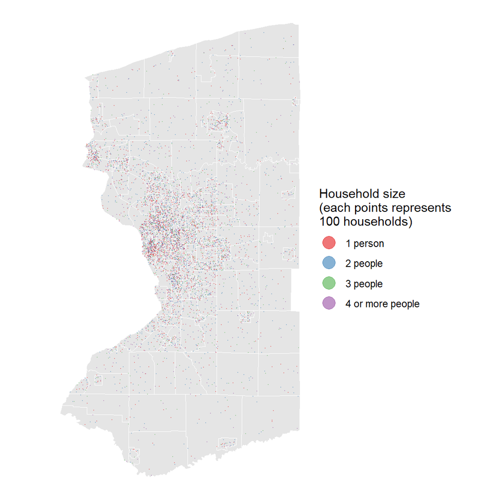

```r
ggplot(census) +
  geom_sf(color = "white") +
  geom_sf(data = hh_size_pts,
          aes(color = hh_size),
          alpha = 0.3,
          size = 0.1) +
  scale_color_brewer("Household size\n(each points represents\n100 households)",
                     palette = "Set1") +
  theme_void()  +
  guides(color = guide_legend(override.aes = list(size=5, alpha = 0.6)))
```

# Create a histogram

A histogram is a helpful way to illustrate the variation in a variable.

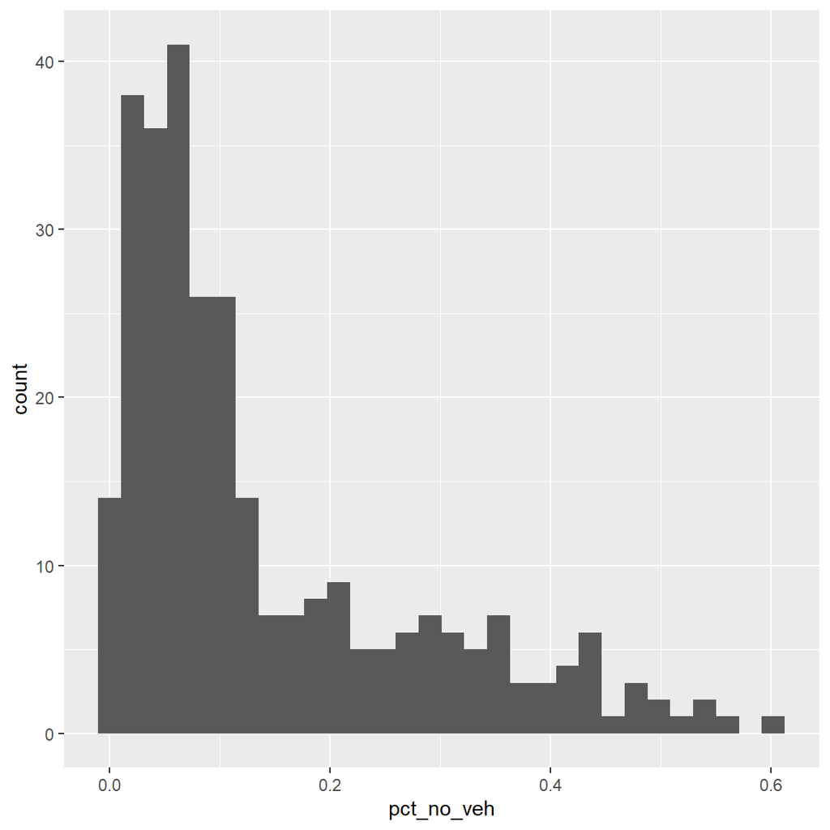

```r
hist <- ggplot(zones) +
  geom_histogram(aes(x = pct_no_veh))

hist
```

You can change the outline and fill colors of the histgram bars using the `fill` and `color` arguments within `geom_histogram()`. You can see a list of all the color names R recognizes by typing `colors()` into your console.

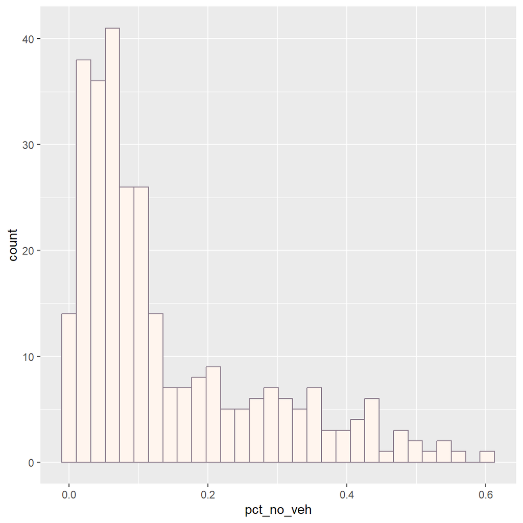

```r
hist <- ggplot(zones) +
  geom_histogram(aes(x = pct_no_veh),
                 fill = "seashell1",
                 color = "thistle4")

hist
```

You could customize the plot further by [applying a theme](https://gsd-ses-5394-s2022.github.io/Richmond/a2_skills.html#apply-a-ggplot-theme) or [customizing the axes].

# Create an interactive map

Even if your deliverable will be all static content in a report, it can be helpful to create an interactive map for your own use to explore your data. For example, it’s a useful way to find the GEOID for a zone in a specific location.

I’ll use the `leaflet` package to create an interactive map. I’ll save it to an html file so I can open the file to view in my browser (once you’ve saved it, the html files will appear in your repository directory on your computer and also in your files pane in RStudio - if you push it to GitHub, you’ll also be able to view it on your [github.io page](https://gsd-ses-5394-s2022.github.io/Richmond/zones/boundaries.html)). I’ll add a popup so you can click on a zone to get the GEOID (which you can then just copy/paste from your browser to use in other code).

```r
library(leaflet)
library(htmlwidgets)

map <- leaflet(census) %>%
  addProviderTiles("Stamen.TonerLite") %>%
  addPolygons(popup = ~GEOID,
              weight = 1,
              opacity = 1,
              highlightOptions =
                highlightOptions(fillColor = "red"))

saveWidget(map, file = 'zones/boundaries.html')
```

# Create a stacked bar chart or pie chart

There is a school of thought that is really against pie charts, and the developers of ggplot are part of that school, so they make it tricky to make a pie chart. You can still do it though because a pie chart is secretly just a stacked bar chart in a polar coordinate system.

First I’ll need to get some total values for the whole region (see the topic on “Get regional data”).

Let’s say I wanted to get the regional share of households that have zero, one, or multiple vehicles. First I’ll set up a list of variables with the numbers of households with zero, one, two, three, or more than three vehicles. I’ll also separately save the variable name for the total number of households.

```r
vars <- c(`Zero vehicles` = 'B08201_002',
          `One vehicle` = 'B08201_003',
          `Two vehicles` = 'B08201_004',
          `Three vehicles` = 'B08201_005',
          `Four or more vehicles` = 'B08201_006')

total_hhs <- 'B08201_001'
```

Now I’ll get the total values for the full study area.

```r
library(tidycensus)

region_vehs <- get_acs(
  geography = "cbsa",
  variables = vars,
  summary_var = total_hhs,
  geometry = FALSE) %>%
  filter(GEOID == "15380") %>%
  mutate(pct = estimate / summary_est) %>%
  select(variable, pct)
```

I could create a stacked bar chart to show those percentages.

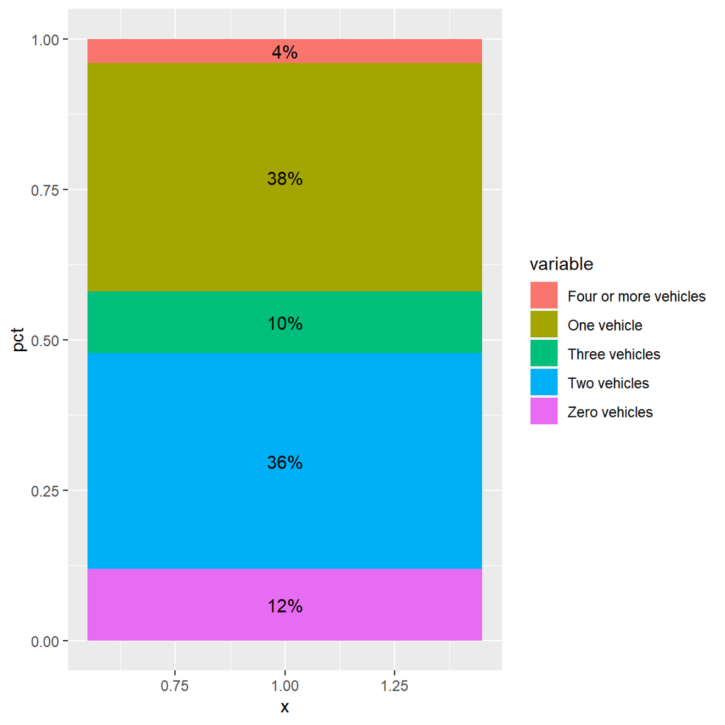

```r
bar_chart <- ggplot(region_vehs, aes(x = 1,
                                     y = pct,
                                     fill = variable,
                                     label = paste0(round(pct*100), "%"))) +
  geom_bar(stat = "identity") +
  geom_text(position = position_stack(vjust = 0.5))


bar_chart
```

I can also wrap that bar chart around a polar coordinate system to make a pie chart.

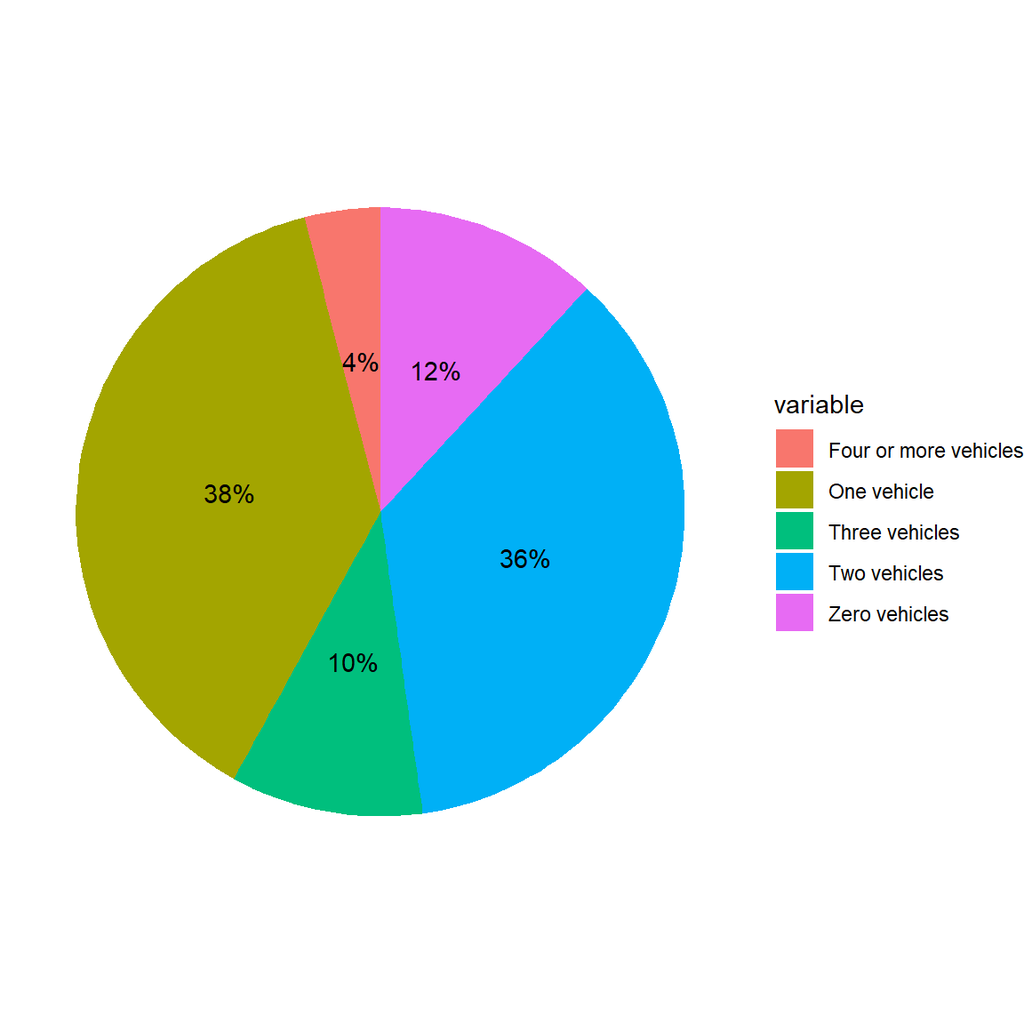

```r
pie_chart <- bar_chart +
  coord_polar(theta = "y") +
  theme_void()

pie_chart
```

# Create a tree map

There is a school of thought that is really against pie charts, and the developers of ggplot are part of that school, so they make it tricky to make a pie chart. Tree maps are nice alternative that avoid some of the pitfalls of pie charts.

First I’ll need to get some total values for the whole region (see the topic on “Get regional data”).

Let’s say I wanted to get the regional share of households that have zero, one, or multiple vehicles. First I’ll set up a list of variables with the numbers of households with zero, one, two, three, or more than three vehicles. I’ll also separately save the variable name for the total number of households.

```r
vars <- c(`Zero vehicles` = 'B08201_002',
          `One vehicle` = 'B08201_003',
          `Two vehicles` = 'B08201_004',
          `Three vehicles` = 'B08201_005',
          `Four or more vehicles` = 'B08201_006')

total_hhs <- 'B08201_001'
```

Now I’ll get the total values for the full study area.

```r
library(tidycensus)

region_vehs <- get_acs(
  geography = "cbsa",
  variables = vars,
  summary_var = total_hhs,
  geometry = FALSE) %>%
  filter(GEOID == "40060") %>%
  mutate(pct = estimate / summary_est) %>%
  select(variable, pct)
```

Now I can use the `treemapify` package to create a tree map.

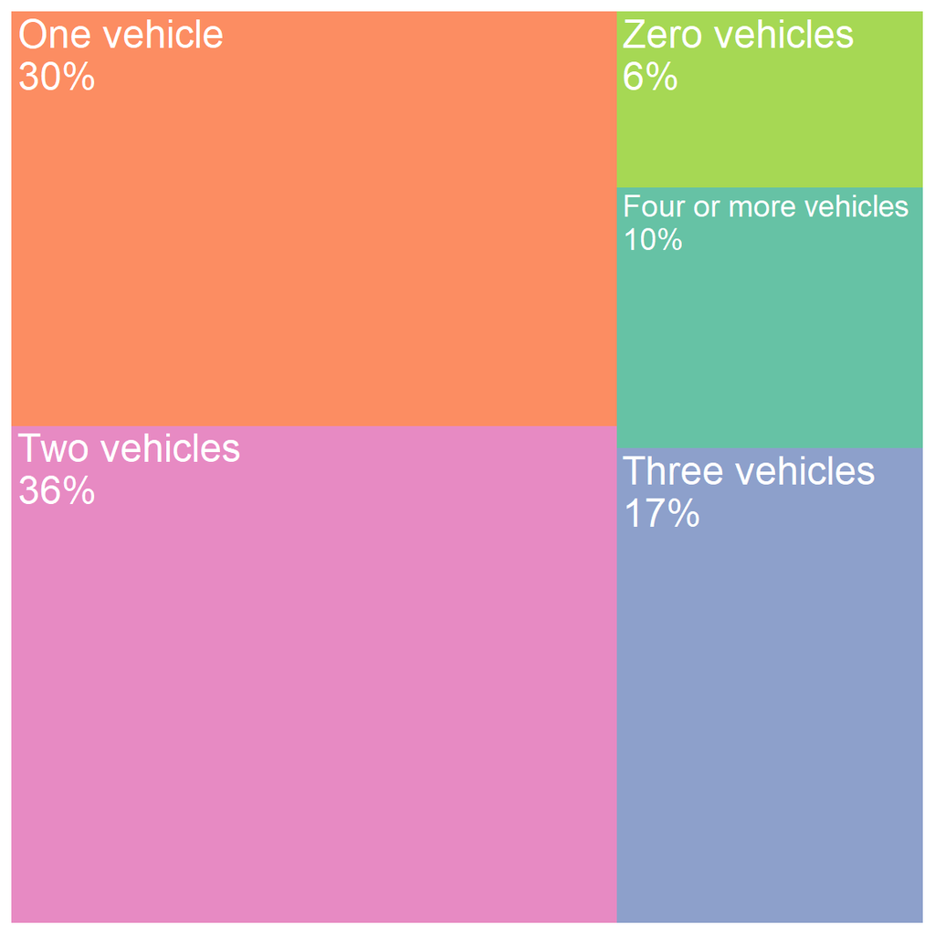

```r
library(treemapify)

ggplot(region_vehs, aes(area = pct, fill= variable)) +
  geom_treemap(show.legend = FALSE, color = NA) +
  geom_treemap_text(aes(label = paste(variable, "\n",
                                      prettyNum(pct * 100, digits = 1),
                                      "%",sep = "")),
                        color = "white") +
  scale_fill_brewer(palette = "Set2")
```

# Customize axes and legends

You’ll likely want to define titles for the axes and legends on any graphics you create. You might also want to control how number are displayed on axes and legends.

Here’s a histogram with default settings for both axes:

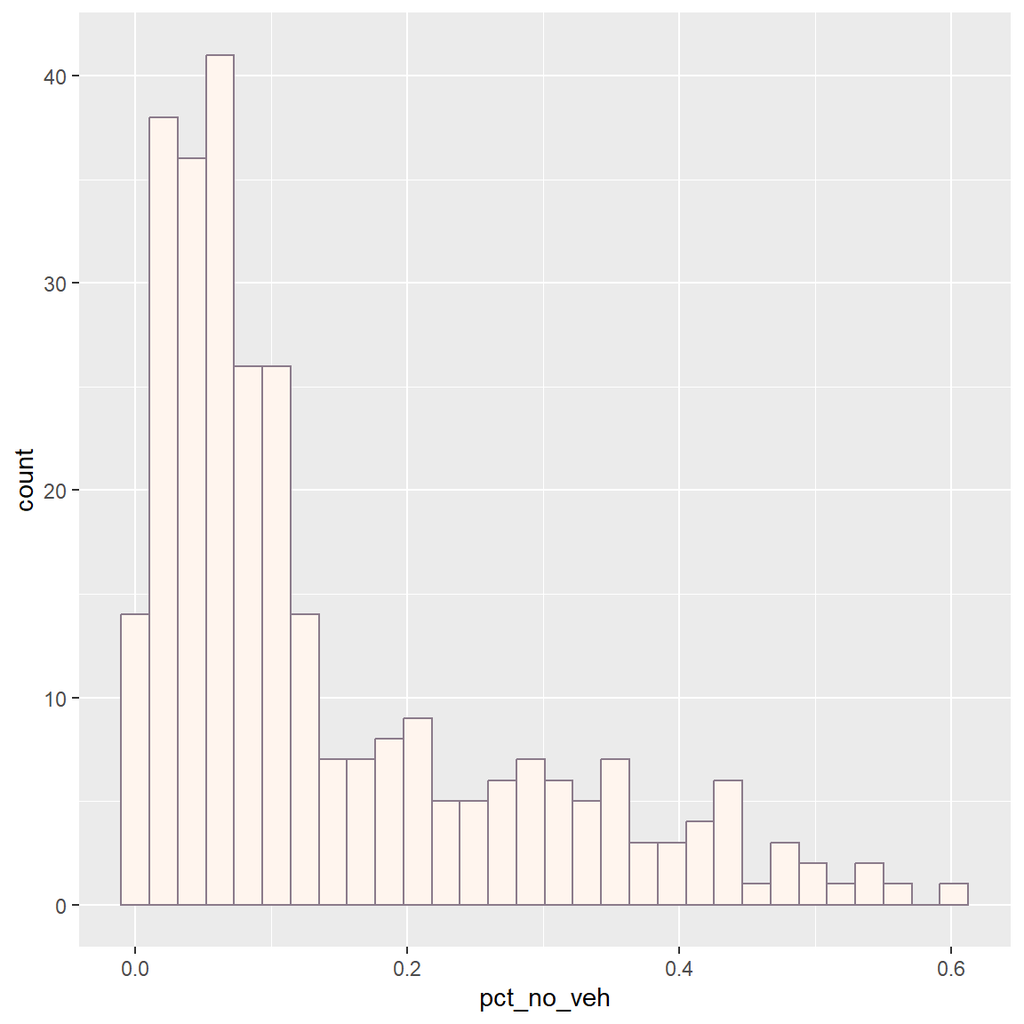

```r
hist
```

The legend titles are just the variable names, and ggplot has created and labeled four or five tick marks on each axis. I can change the title of the y-axis by setting the `name` argument in `scale_y_continuous()`. I can specify where I want the tick marks to be by setting the `breaks` argument to a vector of values (a list within a `c()` function).

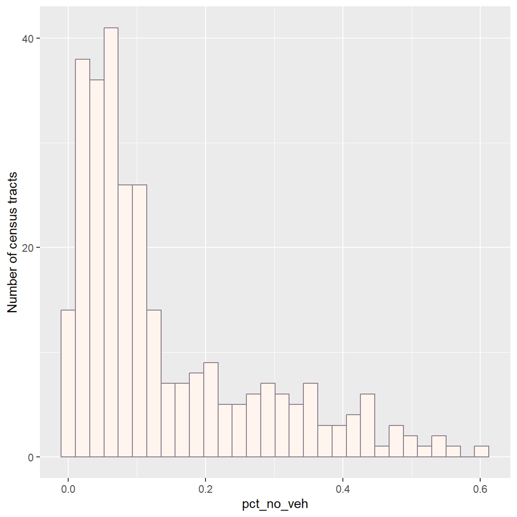

```r
hist +
  scale_y_continuous(name = "Number of census tracts",
                     breaks = c(0, 20, 40, 60, 80, 100))
```

There are some disadvantages to typing out all the breaks for the tick marks manually. For one thing, it leave a lot of room for error if there’s a typo or something. Since you probably want evenly-spaced tick-marks, you can save yourself some typing by using the `seq()` function. The `seq()` function generates a list of numbers from three arguments, the first number, the last number, and the increment value. So if you want numbers that range from zero to 100, increasing by 10, you could type `seq(0, 100, by=10)`.

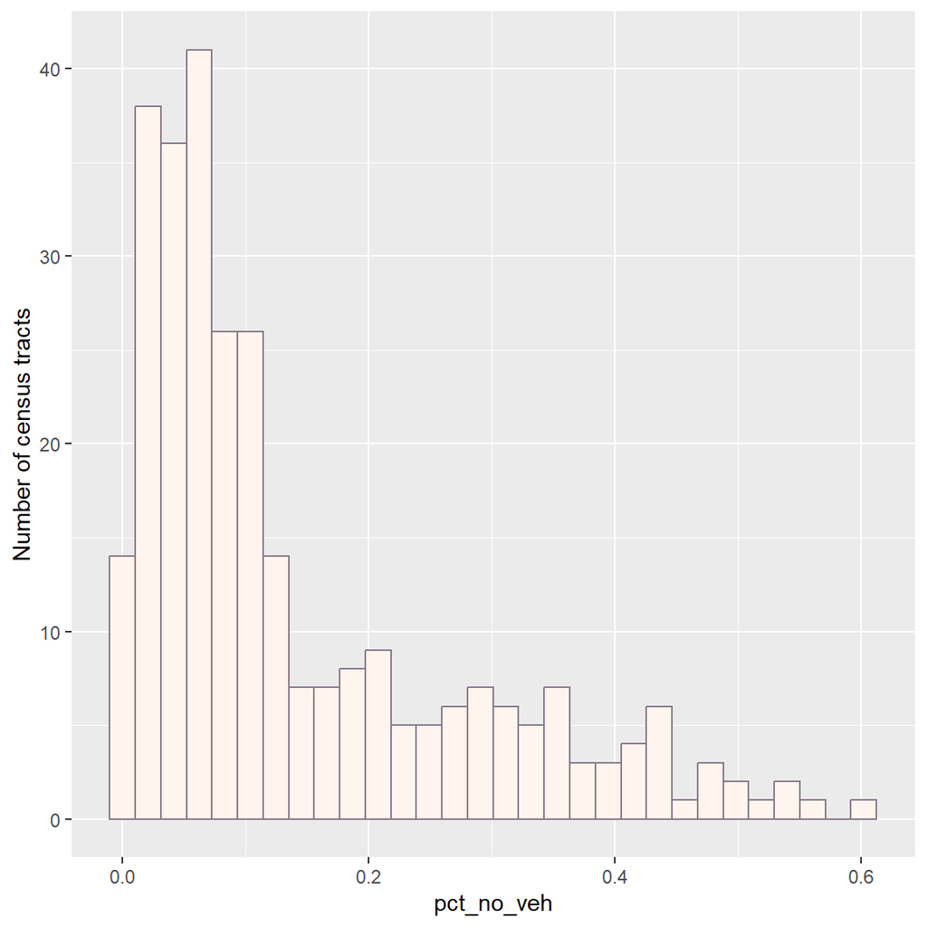

```r
hist +
  scale_y_continuous(name = "Number of census tracts",
                     breaks = seq(0, 100, by =10))
```

I can do the same kind of thing for the x-axis, but this time, I’d like the labels to show up as percentages rather than decimals. I can do this by setting the `labels` argument in `scale_x_continuous()`. So this time, when I create the breaks, I’ll also save them to a variable called `my_brks` so I can use it as a starting point to create labels. The paste() function pastes together numbers and/or characters to create a new character string. In this case, I’m taking the value in `my_brks`, multiplying it by 100, and adding a percentage sign to the end. `sep = ""` means I don’t want a space between the number and the percentage sign.

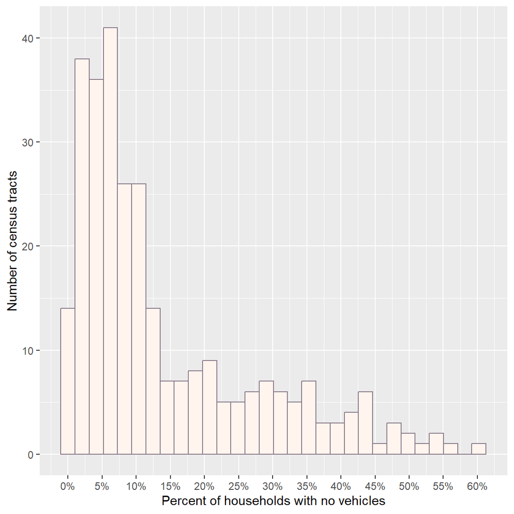

```r
hist +
  scale_y_continuous(name = "Number of census tracts",
                     breaks = seq(0, 100, by =10)) +
  scale_x_continuous(name = "Percent of households with no vehicles",
                     breaks = my_brks <- seq(0, 1, by = 0.05),
                     labels = paste(my_brks * 100, "%", sep = ""))
```

Some variables have a lot of very small values an a smaller number of larger values. This is common for density, as shown in this histogram.

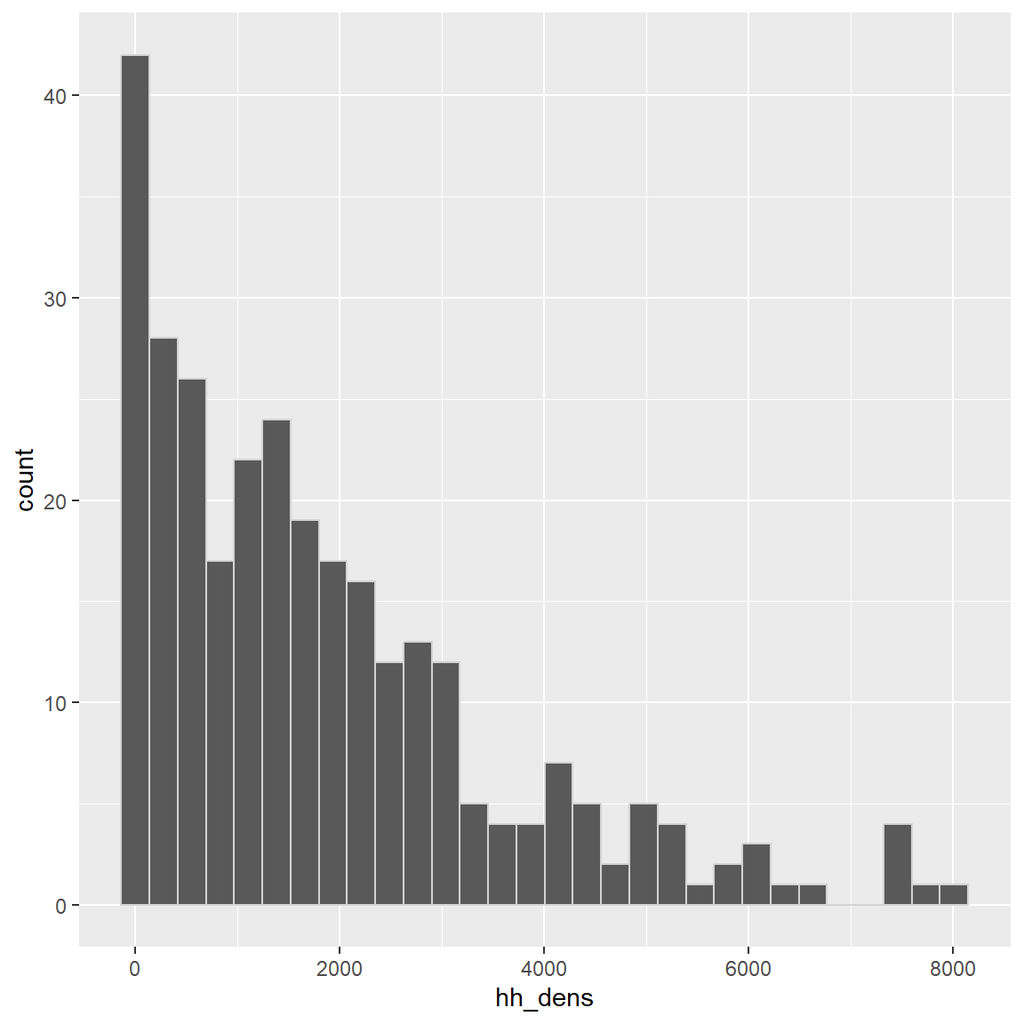

```r
dens_hist
```

In this case, I might find it helpful to log-transform the x-axis by setting `trans = "log"` in the `scale_x_continuous()` function. This doesn’t change the data; it just changes how it is displayed.

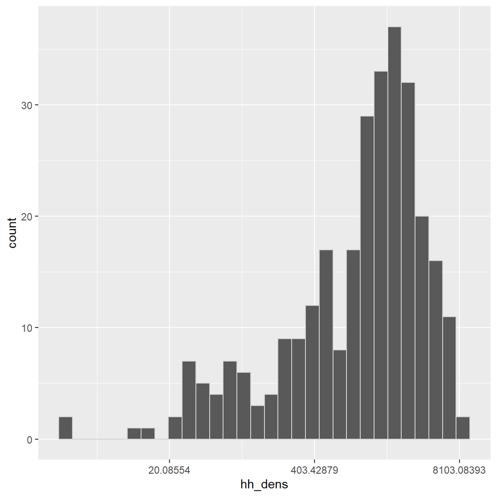

```r
dens_hist +
  scale_x_continuous(trans = "log")
```

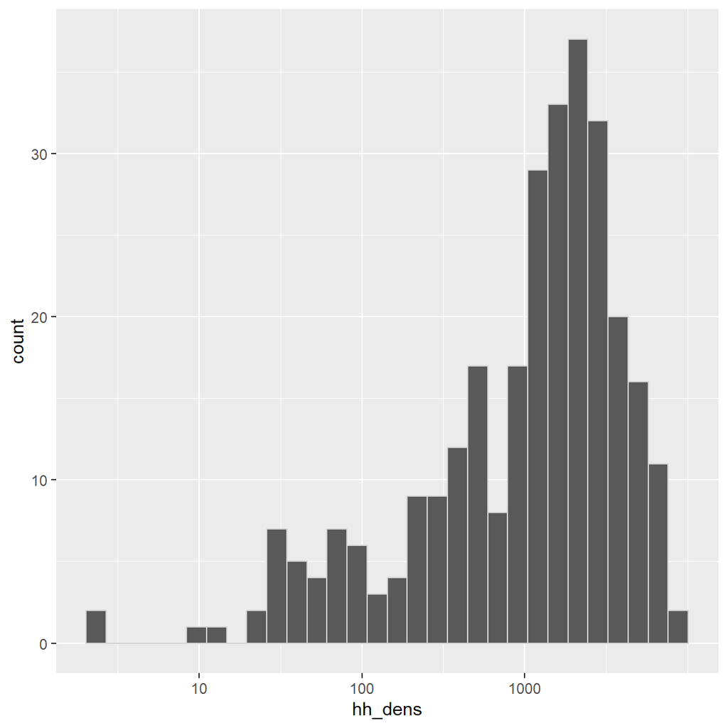

```r
dens_hist +
  scale_x_continuous(trans = "log",
                     breaks = 10^seq(-2, 3, by = 1))
```

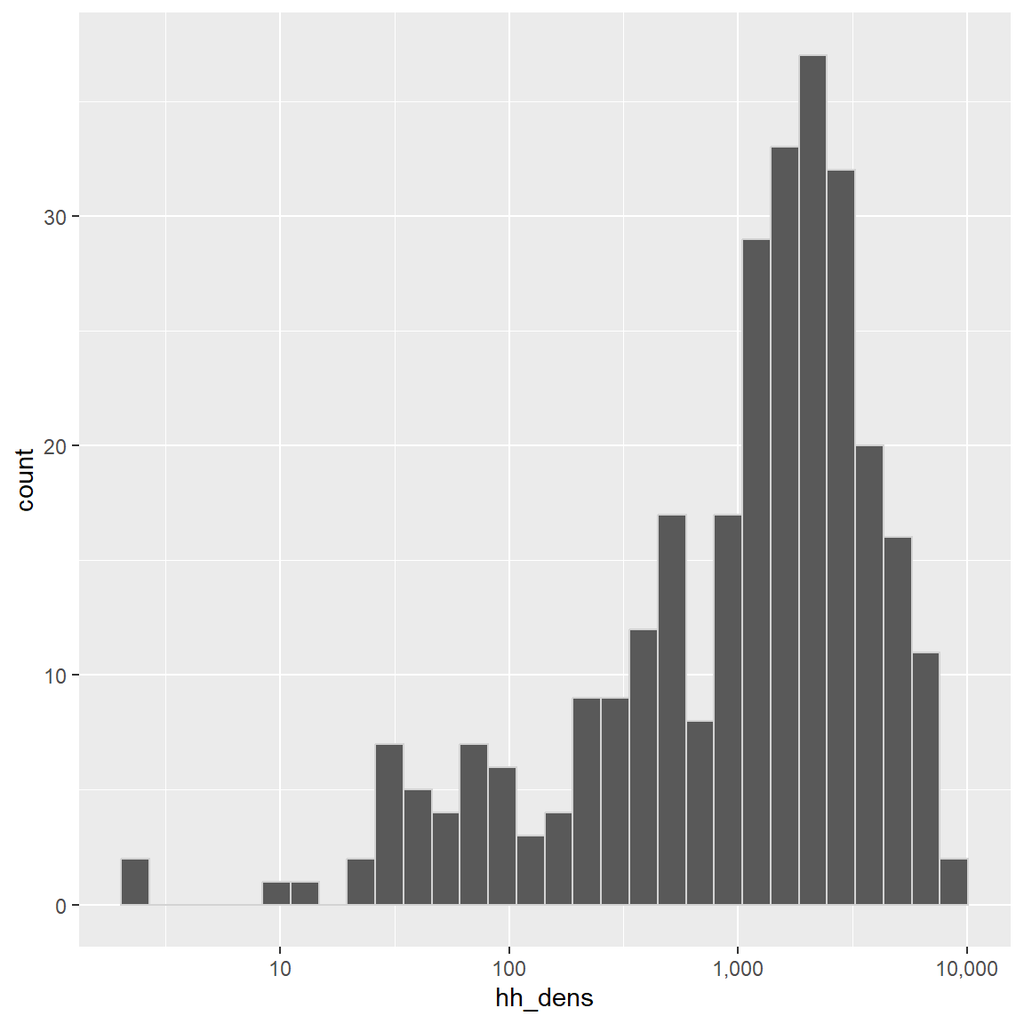

```r
dens_hist +
  scale_x_continuous(trans = "log",
                     breaks = log_brks <- 1 * 10^seq(-1, 4, by = 1),
                     labels = formatC(log_brks, format = "d", big.mark = ","))
```

You’ll probably find `scale_fill_continuous()` useful for the legend on a chloropleth map, and it works the same way. Here’s a chloropleth map with its default legend.

```r
hh_size_map
```

[output not shown]

And here it is with more useful labels on the legend (I’m not advising you use this many tick marks on a color ramp legend - I’m just showing you how to do it).

I’m using `formatC()` to control the number of decimal places to display (`format = "f"` means I want the number to be displayed as a decimal).

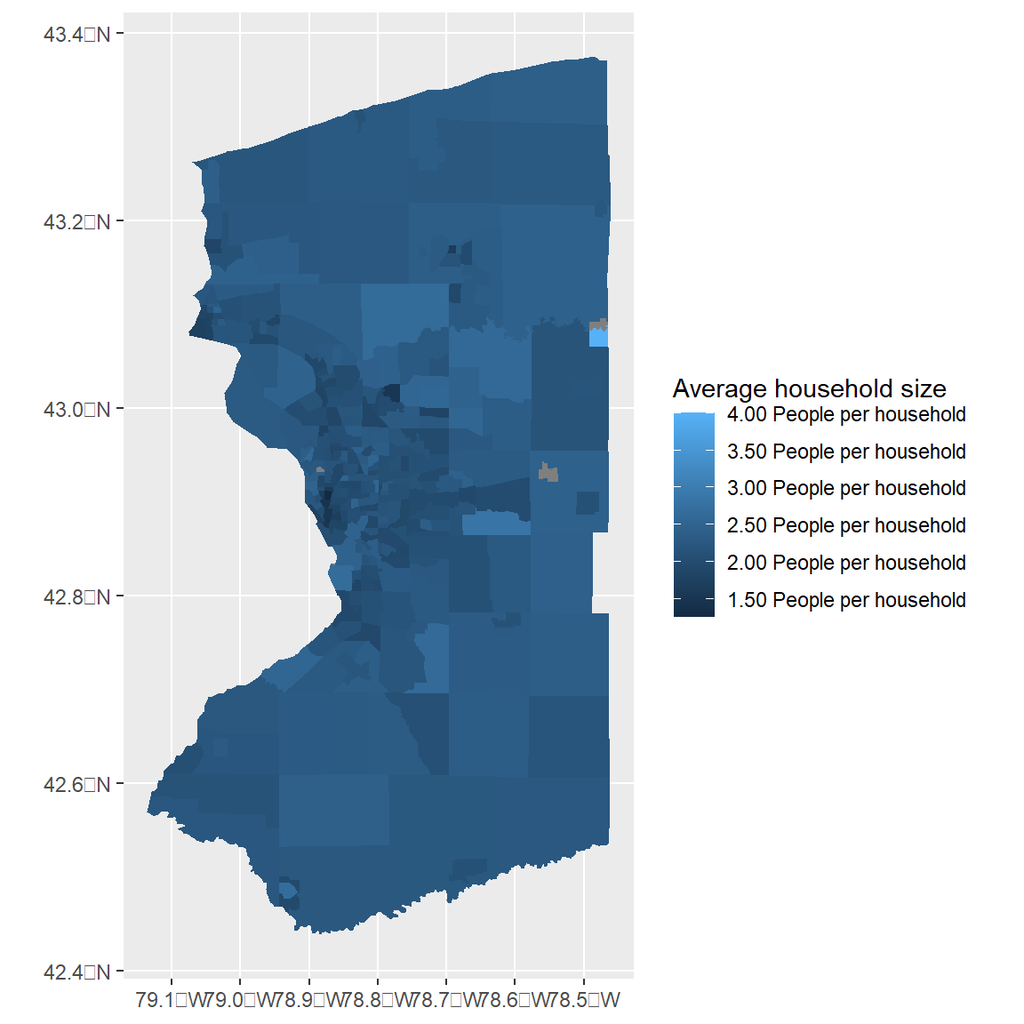

```r
hh_size_map +
  scale_fill_continuous(name = "Average household size",
                        breaks = size_brks <- seq(1, 4, by = 0.5),
                        labels = paste(formatC(size_brks,
                                               format="f",
                                               digits=2),
                                       "People per household"))
```

I can also log-transform a color-ramp. Here’s a chloropleth map of residential density.

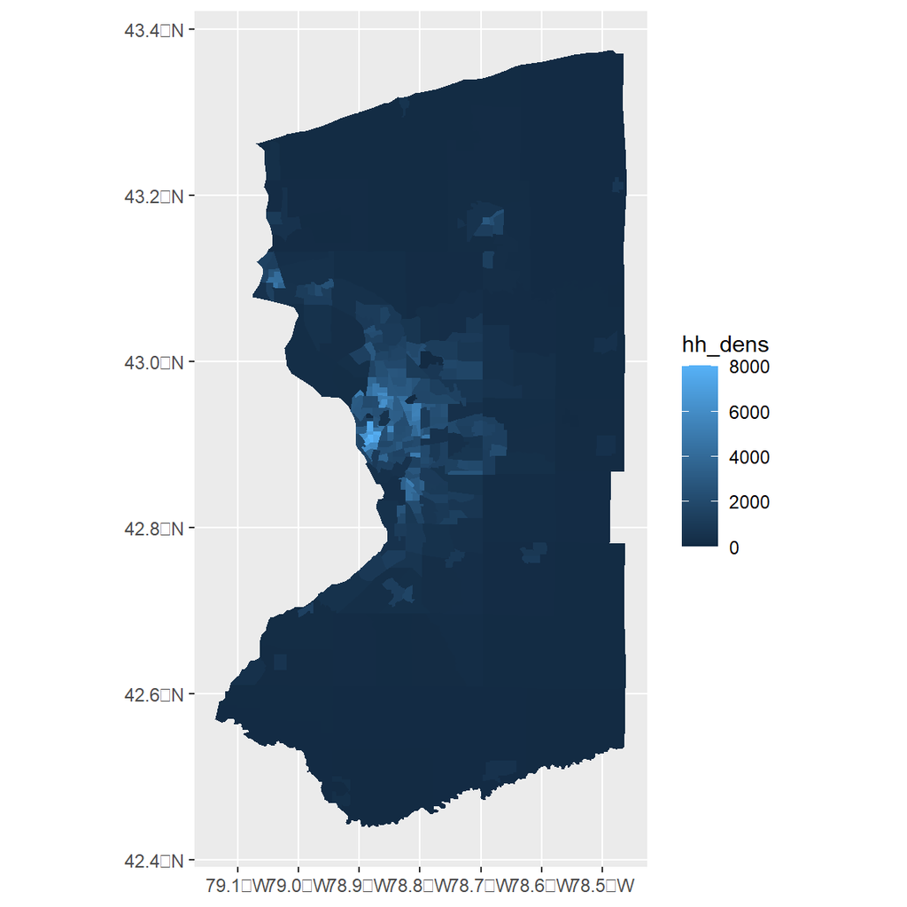

```r
dens_map
```

It’s hard to see much variation in the low-density areas. But if we log-transform the scale, the variation becomes more apparent. You’ll notice I’m using the exact same arguments in scale_fill_continuous that I used above when I log-transformed the x-axis in a histogram.

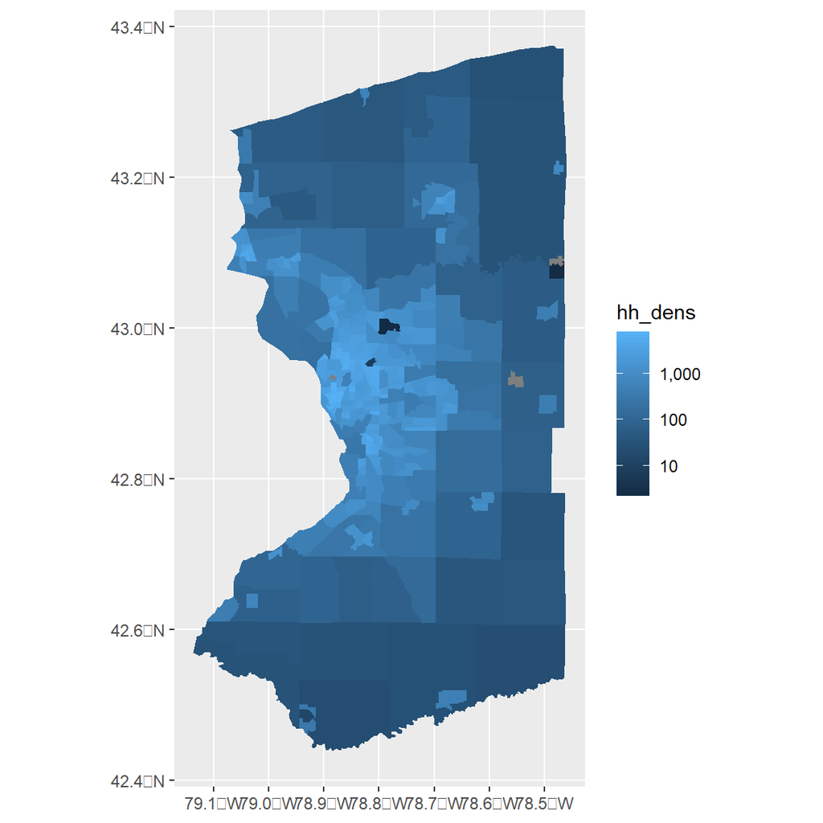

```r
dens_map +
  scale_fill_continuous(trans = "log",
                     breaks = log_brks <- 1 * 10^seq(-1, 4, by = 1),
                     labels = formatC(log_brks, format = "d", big.mark = ","))
```

# Define a color ramp

There are several predefined color palettes you can use, and some useful functions you can use to select colors in `ggplot`.

The [viridis](https://bids.github.io/colormap/) color ramps are meant to be colorblind friendly and to reproduce reasonbly well in grayscale (for example, if someone prints your graphic then photocopies it with a black-and-white printer). There are 4 options.

Option A:

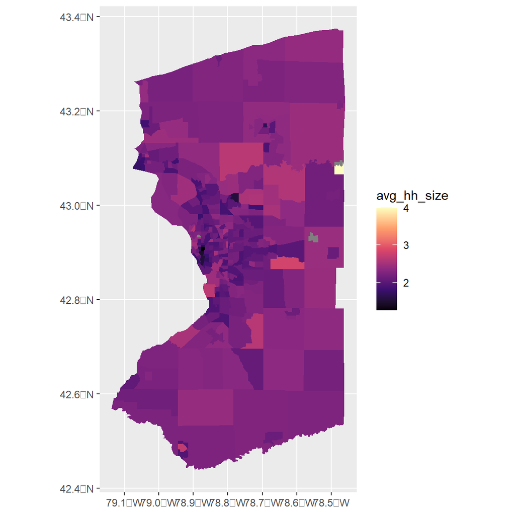

```r
hh_size_map +
  scale_fill_viridis_c(option = "A")
```

Option B:

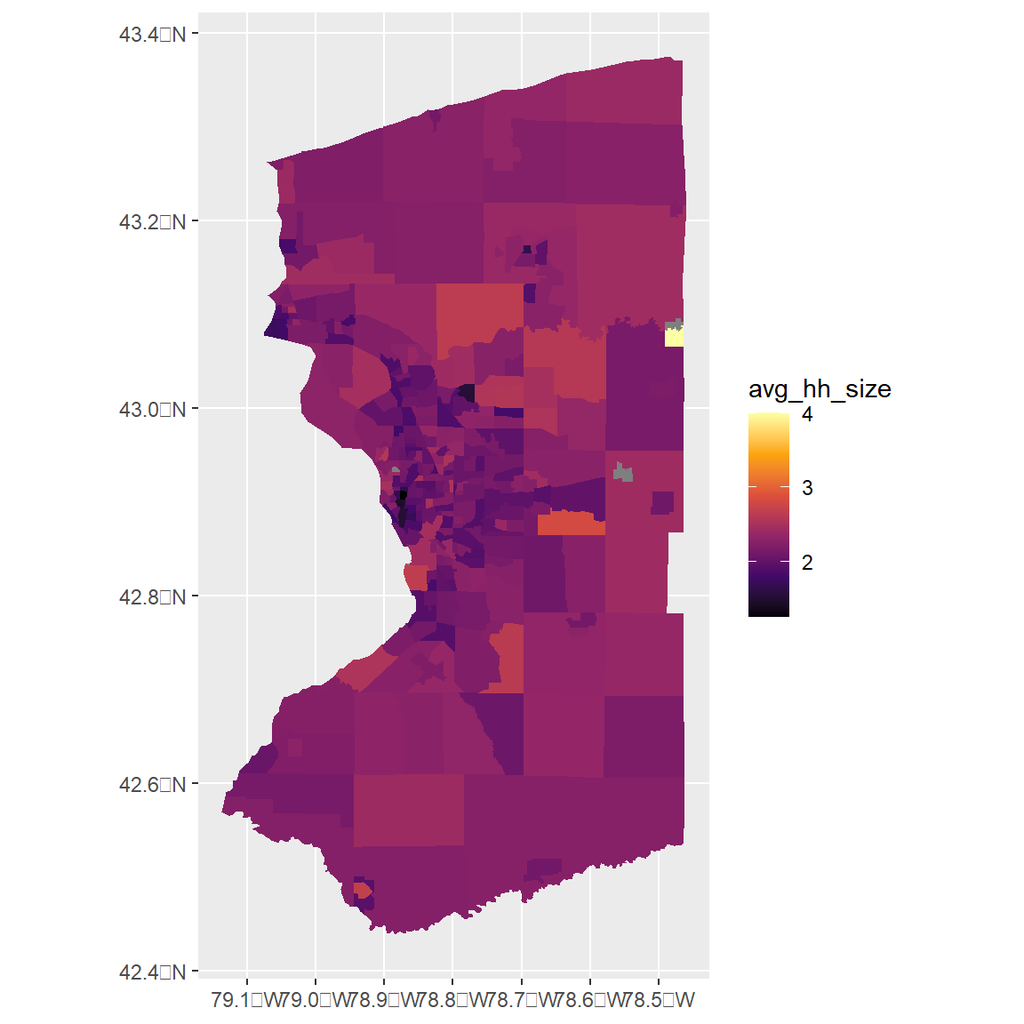

```r
hh_size_map +
  scale_fill_viridis_c(option = "B")
```

Option C:

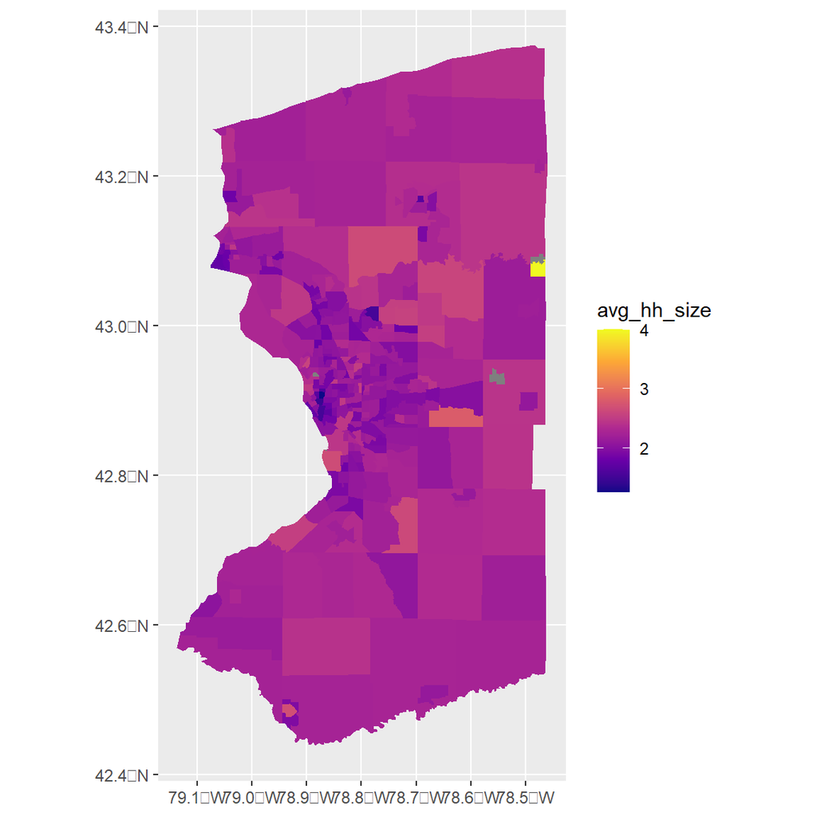

```r
hh_size_map +
  scale_fill_viridis_c(option = "C")
```

Option D (this is the default if you don’t specify an option):

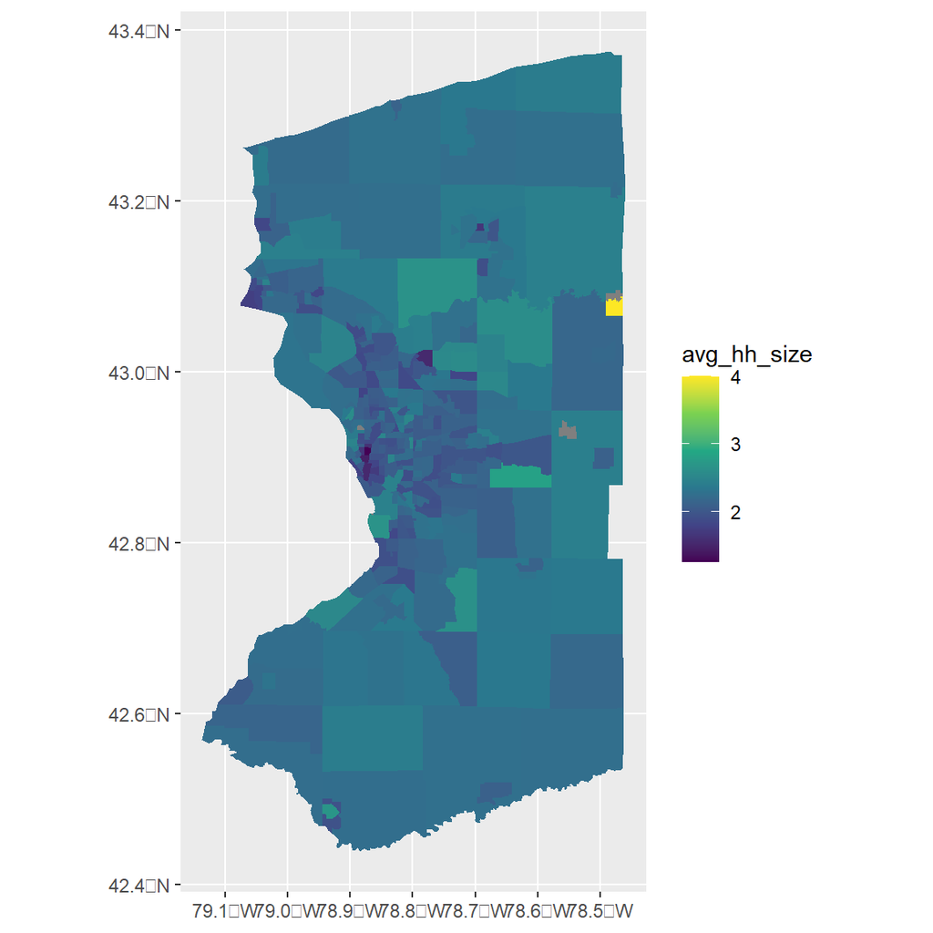

```r
hh_size_map +
  scale_fill_viridis_c(option = "D")
```

You can reverse the color ramp values by setting `begin = 1, end = 0`.

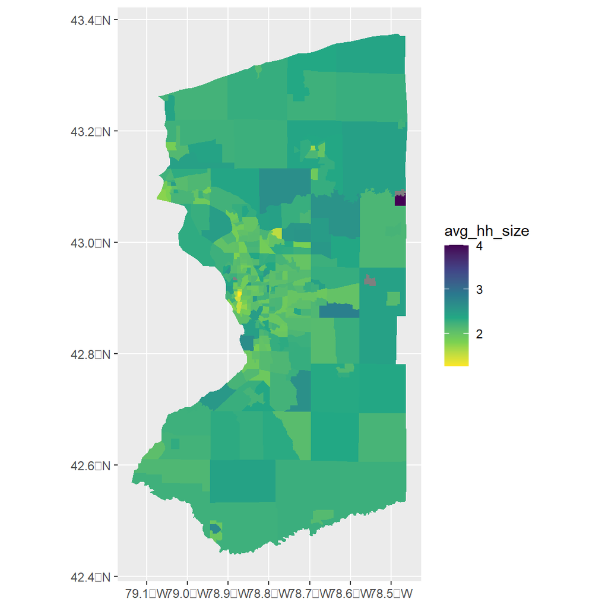

```r
hh_size_map +
  scale_fill_viridis_c(option = "D",
                       begin = 1, end = 0)
```

You can also set up your own color ramp using `scale_fill_gradient()` and specifying low and high values. Here’s as scale that varies continuously from blue to red.

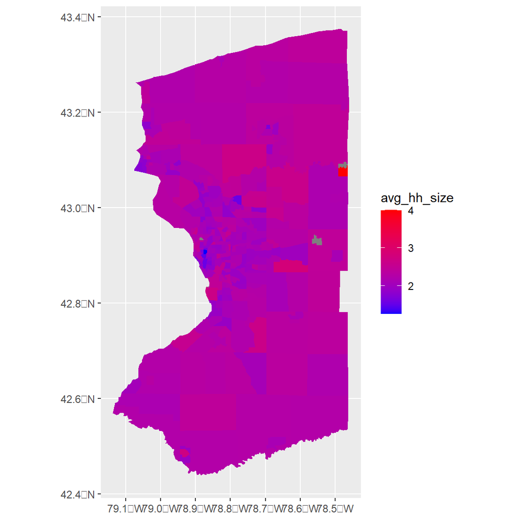

```r
hh_size_map +
  scale_fill_gradient(low = "blue", high = "red")
```

`scale_fill_gradient2()` will let you specify low, medium, and high values. Here’s a ramp that varies from green, to yellow, to red (which would be intuitive because of the analogy to a traffic signal, but not accessible for someone with red-green colorblindness). You also need to set a midpoint value - which I’ll set as the median value.

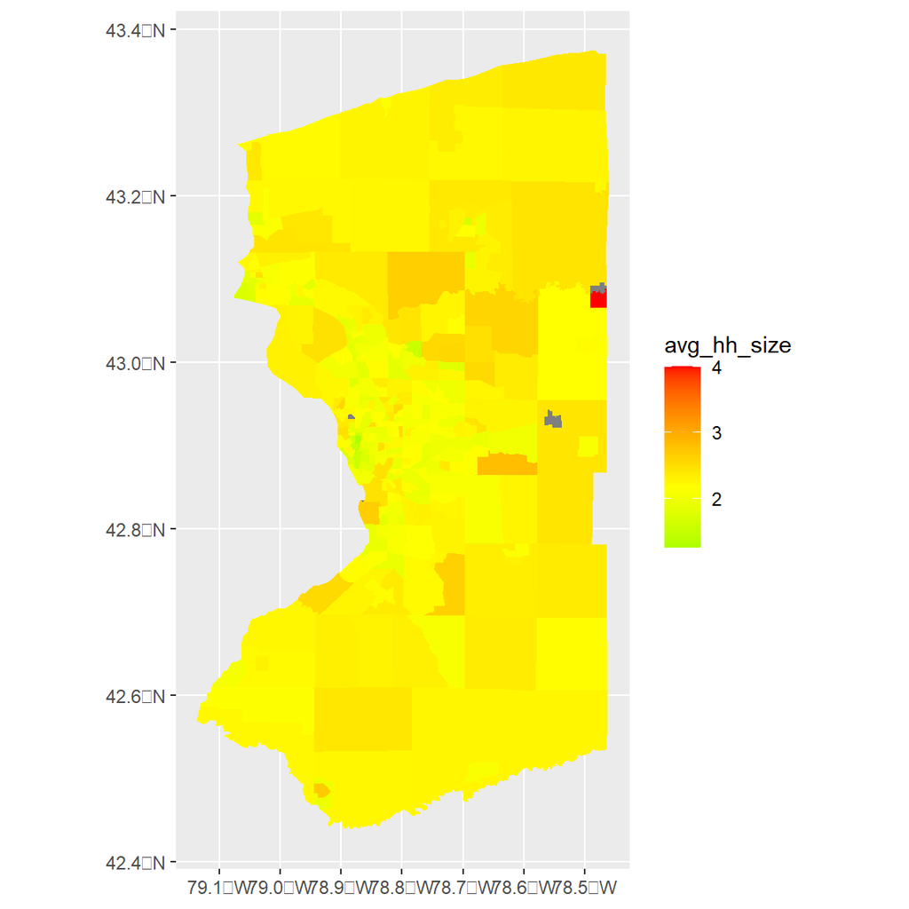

```r
hh_size_map +
  scale_fill_gradient2(low = "green", mid = "yellow", high = "red",
                       midpoint = median(census$avg_hh_size, na.rm = TRUE))
```